# Lending Club

Jas Dinh

April 12, 2022

## Tasks

Perform the following:

- Describe the dataset and any issues with it.
- Generate a minimum of 5 unique visualizations using the data and write a brief description of your observations.
- Additionally, all attempts should be made to make the visualizations visually appealing
- Create a feature set and create a model which predicts interest_rate using at least 2 algorithms. Describe any data cleansing that must be performed and analysis when examining the data.
- Visualize the test results and propose enhancements to the model, what would you do if you had more time. Also describe assumptions you made and your approach.

```r
lender <- read.csv("loans_full_schema.csv")

library(usmap)
library(dplyr)
```

```r
library(ggplot2)
library(cluster)
library(GGally)
```

## Data Exploration

Because of limited time, I ran data exploration using a pandas profiling package in Jupyter Notebook and have appended the code here. The report can be found here

```python
import pandas as pd
import sys;
!{sys.executable} -m pip install pandas-profiling;
data = pd.read_csv("loans_full_schema.csv")
import pandas_profiling
profile = pandas_profiling.ProfileReport(data)
profile.to_file("lender.html")
```

The dataset has 55 total variables and 10,000 observations. The dataset is missing 7.7% of its cells. There are 19 categorical variables and 36 numerical variables.

## Predictive Modeling

With the profiling, I was able to see that the interest_rate has a high correlation with grade, sub_grade, and paid_interest variables.

### Generalized Linear Modeling

```r
featureSet <- lender %>% select(interest_rate, grade, sub_grade, paid_interest)

interestGrade <- glm(interest_rate ~ grade, data = featureSet)
summary(interestGrade)
```

```
##
## Call:
## glm(formula = interest_rate ~ grade, data = featureSet)
##
## Deviance Residuals:
##      Min        1Q    Median        3Q       Max
## -13.1135   -0.6635   -0.0967    0.8633    2.7365
##
## Coefficients:
##             Estimate Std. Error t value Pr(>|t|)
## (Intercept)  6.74263    0.02234  301.79   <2e-16 ***
## gradeB       3.78147    0.03006  125.81   <2e-16 ***
## gradeC       7.43407    0.03101  239.70   <2e-16 ***
## gradeD      12.37082    0.03672  336.93   <2e-16 ***
## gradeE      18.36077    0.06452  284.56   <2e-16 ***
## gradeF      22.65927    0.14718  153.95   <2e-16 ***
## gradeG      24.05987    0.32061   75.04   <2e-16 ***
## ---
## Signif. codes:  0 '***' 0.001 '**' 0.01 '*' 0.05 '.' 0.1 ' ' 1
##
## (Dispersion parameter for gaussian family taken to be 1.227505)
##
##     Null deviance: 250085  on 9999  degrees of freedom
## Residual deviance:  12266  on 9993  degrees of freedom
## AIC: 30438
##
## Number of Fisher Scoring iterations: 2
```

With the linear model of grade of the loan versus the interest rate, as the grade of the loan increases from grade A to grade G, the interest rate also increases.

```r
interestSubGrade <- glm(interest_rate ~ sub_grade, data = featureSet)
summary(interestSubGrade)
```

```
##
## Call:
## glm(formula = interest_rate ~ sub_grade, data = featureSet)
##
## Deviance Residuals:
##      Min        1Q    Median        3Q       Max
## -14.0964   -0.0059    0.0037    0.0043    0.2936
##
## Coefficients:
##              Estimate Std. Error t value Pr(>|t|)
## (Intercept)  5.315545   0.009823  541.13   <2e-16 ***
## sub_gradeA2  0.760080   0.013466   56.45   <2e-16 ***
## sub_gradeA3  1.400645   0.013315  105.19   <2e-16 ***
## sub_gradeA4  2.030177   0.012968  156.55   <2e-16 ***
## sub_gradeA5  2.650104   0.013433  197.28   <2e-16 ***
## sub_gradeB1  4.120127   0.012626  326.31   <2e-16 ***
## sub_gradeB2  4.610568   0.012662  364.14   <2e-16 ***
## sub_gradeB3  5.100862   0.013111  389.05   <2e-16 ***
## sub_gradeB4  5.589722   0.012906  433.10   <2e-16 ***
## sub_gradeB5  6.670414   0.012689  525.66   <2e-16 ***
## sub_gradeC1  7.300033   0.012833  568.83   <2e-16 ***
## sub_gradeC2  8.270521   0.012949  638.69   <2e-16 ***
## sub_gradeC3  8.760802   0.013333  657.08   <2e-16 ***
## sub_gradeC4  9.730499   0.013321  730.47   <2e-16 ***
## sub_gradeC5 10.700372   0.013466  794.64   <2e-16 ***
## sub_gradeD1 11.922167   0.014971  796.34   <2e-16 ***
## sub_gradeD2 12.883402   0.014918  863.59   <2e-16 ***
## sub_gradeD3 13.857413   0.015081  918.89   <2e-16 ***
## sub_gradeD4 14.780862   0.016516  894.96   <2e-16 ***
## sub_gradeD5 16.271860   0.015872 1025.21   <2e-16 ***
## sub_gradeE1 17.591284   0.033010  532.91   <2e-16 ***
## sub_gradeE2 18.560946   0.028476  651.82   <2e-16 ***
## sub_gradeE3 19.530208   0.025579  763.52   <2e-16 ***
## sub_gradeE4 20.500893   0.025579  801.47   <2e-16 ***
## sub_gradeE5 21.180719   0.023323  908.15   <2e-16 ***
## sub_gradeF1 23.404455   0.037550  623.28   <2e-16 ***
## sub_gradeF2 24.374455   0.067977  358.57   <2e-16 ***
## sub_gradeF3 24.854455   0.067977  365.63   <2e-16 ***
## sub_gradeF4 25.334455   0.090777  279.09   <2e-16 ***
## sub_gradeF5 25.434455   0.101372  250.90   <2e-16 ***
## sub_gradeG1 25.474455   0.061630  413.35   <2e-16 ***
## sub_gradeG4 25.624455   0.202030  126.83   <2e-16 ***
## ---
## Signif. codes:  0 '***' 0.001 '**' 0.01 '*' 0.05 '.' 0.1 ' ' 1
##
## (Dispersion parameter for gaussian family taken to be 0.04071948)
##
##     Null deviance: 250085.49  on 9999  degrees of freedom
## Residual deviance:    405.89  on 9968  degrees of freedom
## AIC: -3597.8
##
## Number of Fisher Scoring iterations: 2
```

The linear model of the sub grade of the loan versus the interest rate also shows the same pattern. As the sub grade increases, the interest rate increases.

```r
interestPaid <- glm(interest_rate ~ paid_interest, data = featureSet)
summary(interestPaid)
```

```
##
## Call:
## glm(formula = interest_rate ~ paid_interest, data = featureSet)
##
## Deviance Residuals:
##      Min        1Q    Median        3Q       Max
## -10.3197   -3.2379   -0.6205    2.4795   20.1539
##
## Coefficients:
##                Estimate Std. Error t value Pr(>|t|)
## (Intercept)   9.4448784  0.0656559   143.9   <2e-16 ***
## paid_interest 0.0049738  0.0000829    60.0   <2e-16 ***
## ---
## Signif. codes:  0 '***' 0.001 '**' 0.01 '*' 0.05 '.' 0.1 ' ' 1
##
## (Dispersion parameter for gaussian family taken to be 18.39201)
##
##     Null deviance: 250085  on 9999  degrees of freedom
## Residual deviance: 183883  on 9998  degrees of freedom
## AIC: 57502
##
## Number of Fisher Scoring iterations: 2
```

The linear model of the amount of interest paid so far and the current interest rate of the loan shows a positive relationship. As the paid interest increases by $1, the interest rate increases by 0.0049738%.

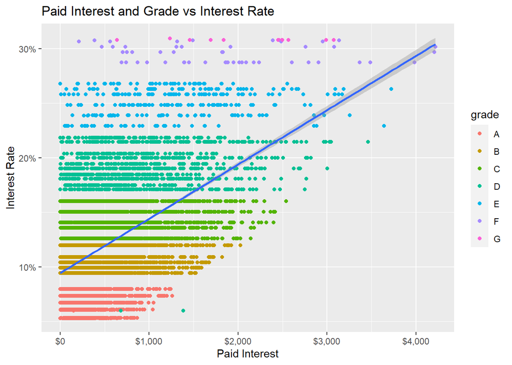

```r
ggplot(featureSet, aes(x = paid_interest, y = interest_rate)) + geom_point(aes(color = grade)) + geom_smooth(method = "lm") + labs(title = "Paid Interest and Grade vs Interest Rate", x = "Paid Interest", y = "Interest Rate") + scale_x_continuous(labels=scales::dollar_format())+ scale_y_continuous(labels=scales::percent_format(scale =1 ))
```

### Cluster Analysis

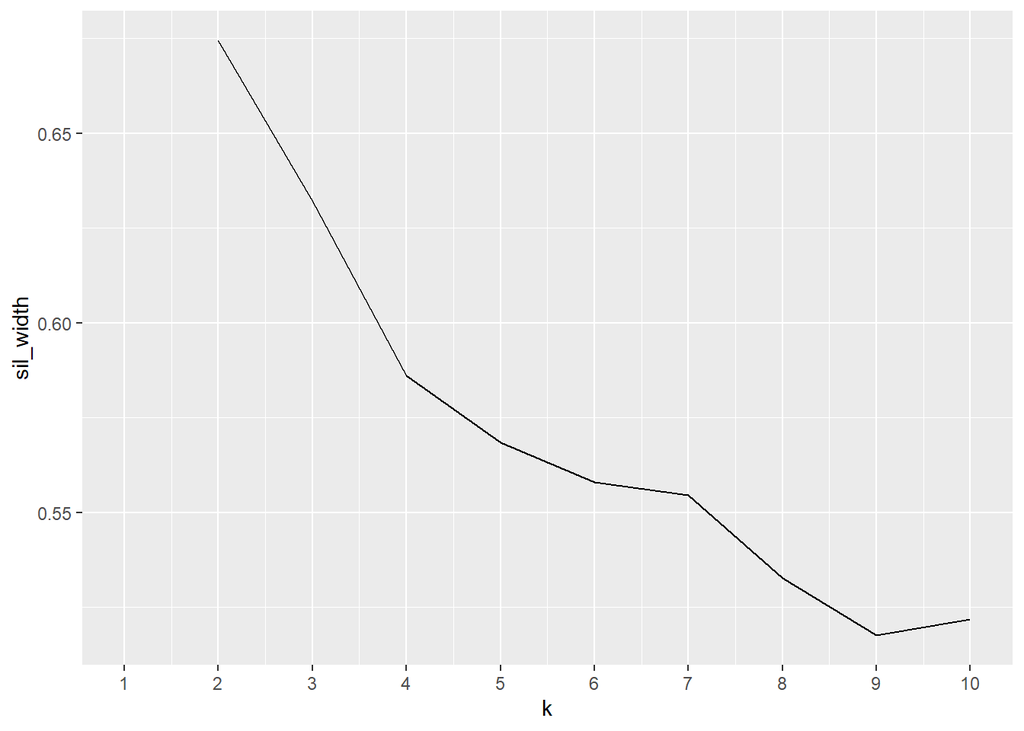

```r
featureset2 <- lender %>% select(interest_rate, paid_interest, total_debit_limit, debt_to_income_joint)
featureset2 <- na.omit(featureset2)

sil_width <- vector()
for (i in 2:10) {
    kms <- kmeans(featureset2, centers = i)
    sil <- silhouette(kms$cluster, dist(featureset2))
    sil_width[i] <- mean(sil[, 3])
}
ggplot() + geom_line(aes(x = 1:10, y = sil_width)) + scale_x_continuous(name = "k",
    breaks = 1:10)
```

[figure not shown]

```r
# 2 clusters
pam1 <- featureset2 %>% pam(k = 2)
plot(pam1, which = 2, border = NA, col = "red")
```

```r
featurePam <- featureset2 %>% pam(2)
```

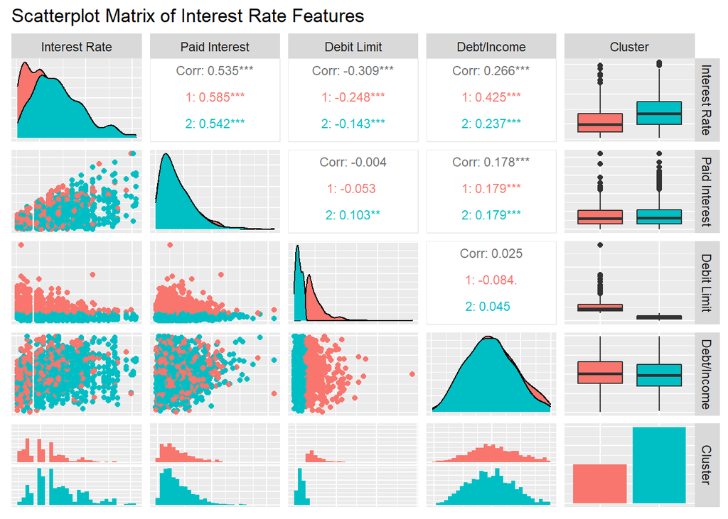

```r
featureset2 %>% mutate(cluster = as.factor(pam1$clustering)) %>%
    ggpairs(aes(color = cluster), columnLabels = c("Interest Rate","Paid Interest","Debit Limit","Debt/Income", "Cluster"),
        upper = list(continuous = wrap('cor', size = 3)),
        title = "Scatterplot Matrix of Interest Rate Features") +
  theme(axis.line=element_blank(),
        axis.text=element_blank(),
        axis.ticks=element_blank())
```

Overall, if I had more time, I would run more regression prediction models on interest rate as well as investigate different variables for cluster analysis.

## Visualizations

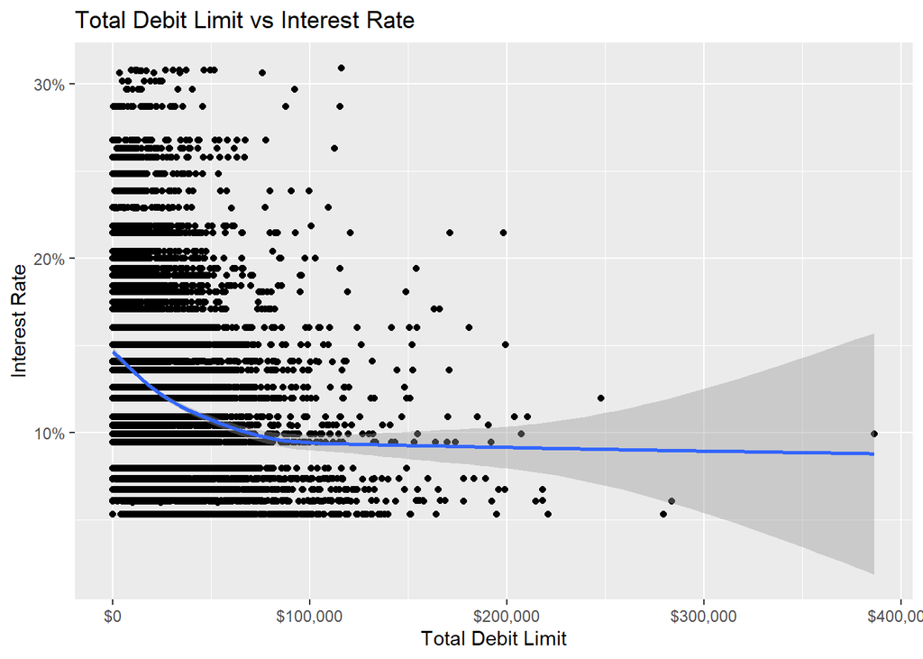

```r
ggplot(lender, aes(x = total_debit_limit, y = interest_rate)) + geom_point() + geom_smooth() + labs(title = "Total Debit Limit vs Interest Rate", x = "Total Debit Limit", y = "Interest Rate") + scale_x_continuous(labels=scales::dollar_format())+ scale_y_continuous(labels=scales::percent_format(scale =1 ))
```

For the third visualization, I noticed that total debit limit was negatively correlated with interest rate and I wanted to investigate the relationship further. It seems that as the total debit limit increases, the interest rate decreases exponentially; however, there is increased uncertainty past a total debit limit of $100,000 that averages around a 10% interest rate.

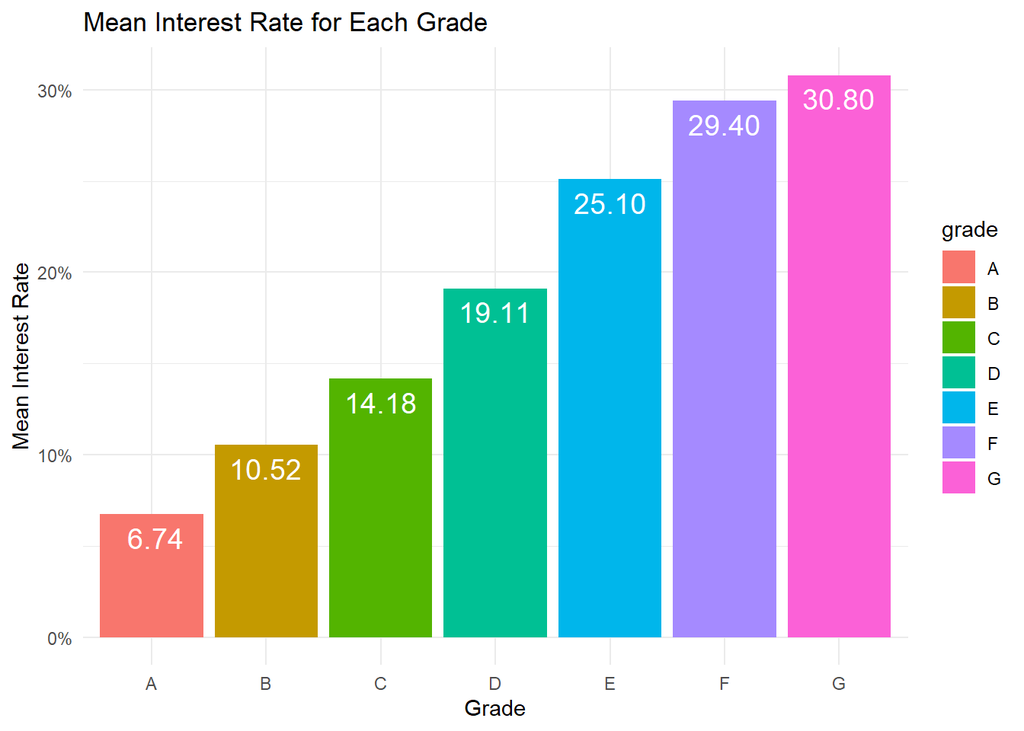

```r
gradeIR <- featureSet %>% group_by(grade) %>% summarize(meanIR = mean(interest_rate))
ggplot(gradeIR, aes(x = grade, y = meanIR)) + geom_bar(stat = "identity", aes(fill = grade)) + labs(title = "Mean Interest Rate for Each Grade", x= "Grade", y = "Mean Interest Rate") +   geom_text(aes(label= format(round(meanIR, 2), nsmall = 2)), vjust=1.6, color="white", size=5) + scale_y_continuous(labels=scales::percent_format(scale = 1 )) + theme_minimal()
```

For fourth visualization, I investigated the mean interest rate per grade.

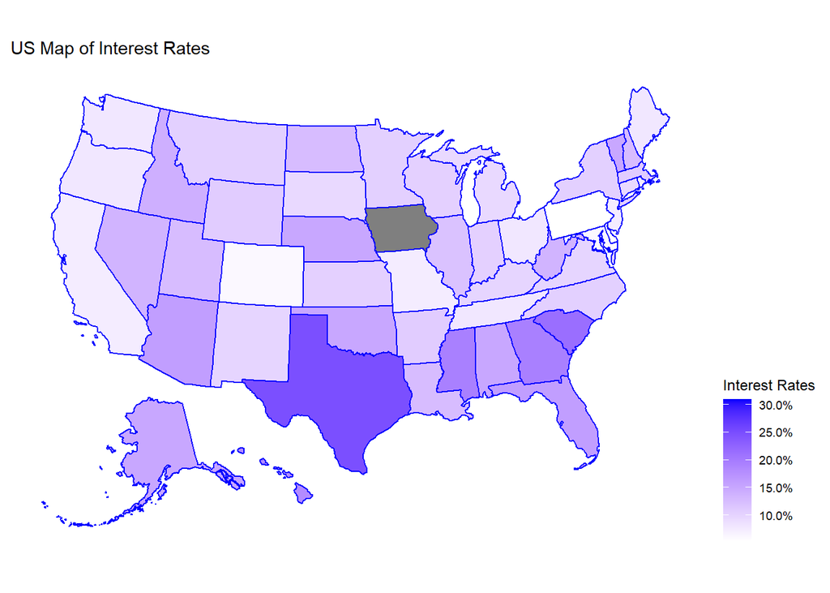

```r
plot_usmap(data = lender, values = "interest_rate", color = "blue") + scale_fill_continuous(low = "white", high = "blue", name = "Interest Rates", label = scales::percent_format(scale =1 )) +
  labs(title = "US Map of Interest Rates") + theme(legend.position = "right")
```

For the last visualization, I analyzed the interest rates across states and it is clear that Texas has the highest interest rate.